# Balance Assessment and Survival Analysis | Tamsulosin vs 5ARI

Jacob Simmering, PhD https://jacobsimmering.com (University of Iowa)https://uiowa.edu  
2023-11-09

```r
library("Rcpp")
library(tidyverse)
library(gtsummary)
library(survival)
library(effectsize)
library(patchwork)
```

This file was compiled on 2023-11-09 13:24:06 by `jsimmeri` on MNF091.

The script `analysis_functions.R` provides:

1. some functions for summarizing the cohort and building tables that are shared across scripts
2. code to load the entire collection out outcomes data (which it returns as `model_data` to the workspace)
3. sets `root_dir` according to the location where the script is being run to handle different syntax for referring to network drives in MacOS and CentOS

```r
source("~/projects/dlb-tz/analysis/analysis_functions.R")
```

## Data Load

### Unadjusted Data

The tibble `model_data` is loaded by `analysis_functions` `model_data` contains data on all users of the three drugs. We want to reduce that here to just tamsulosin and 5ARI.

```r
model_data <- model_data %>%
  filter(two_rx == TRUE) %>%
  filter(drug %in% c("5ari", "tamsulosin")) %>%
  mutate(treatment = drug == "tamsulosin")
```

### Matches

We also want to load our matching results:

```r
matches <- read_rds(glue::glue("/{shared_dir}/lss_jsimmeri/LBD/matches_tam_5ari_2rx.rds"))
```

And using the matches, build matched versions of the tamsulosin versus 5ARI model data:

```r
matched_model_data <- model_data %>%
  select(-treatment) %>%
  inner_join(matches,
    by = "enrolid")
```

## Balance and Cohort Description

### Before Matching

```r
describe_cohort(model_data)
```

| Group | Characteristic | 5ari, N = 80,158 | tamsulosin, N = 437,045 | Difference |
| --- | --- | --- | --- | --- |
| Age and Medication Start Time | Age at Index Date | 62 (54, 71) | 62 (56, 71) | -0.10 |
|  | Medication Index Date | 2,010.0 (2,008.0, 2,013.0) | 2,012.0 (2,008.0, 2,014.0) | -0.27 |
| Duration of Enrollment Time | Lookback Time (Years) | 3.2 (1.8, 5.6) | 3.6 (2.0, 6.3) | -0.18 |
|  | Follow Up Time (Years) | 2.23 (0.98, 4.42) | 1.90 (0.86, 3.78) | 0.14 |
| Rates of Inpatient and Outpatient Encounters | Inpatient Events Per Year | 0.00 (0.00, 0.00) | 0.00 (0.00, 0.22) | -0.18 |
|  | Outpatient Events Per Year | 9 (5, 16) | 10 (5, 18) | -0.11 |
|  | Mean Number of DX Codes Per Outpatient Event | 1.40 (1.20, 1.87) | 1.56 (1.27, 2.09) | -0.24 |
|  | Outpatient DX Code Incidence Per Year | 0.04 (0.02, 0.07) | 0.04 (0.02, 0.08) | -0.16 |
|  | mean_ndx_out_rate | 13 (7, 24) | 16 (9, 29) | -0.16 |
| Elixhauser/AHRQ Comorbidity Flags | Alcohol Abuse | 1,152 (1.4%) | 11,379 (2.6%) | 0.03 |
|  | Anemia | 9,308 (11.6%) | 68,691 (15.7%) | 0.04 |
|  | Blood Loss | 913 (1.1%) | 7,232 (1.7%) | 0.01 |
|  | Heart Failure | 5,398 (6.7%) | 42,970 (9.8%) | 0.04 |
|  | Coagulopathy | 2,360 (2.9%) | 18,949 (4.3%) | 0.03 |
|  | Depression | 5,527 (6.9%) | 43,797 (10.0%) | 0.04 |
|  | Diabetes Without Complications | 15,970 (19.9%) | 121,292 (27.8%) | 0.06 |
|  | Diabetes With Complications | 5,141 (6.4%) | 46,695 (10.7%) | 0.05 |
|  | Drug Abuse | 576 (0.7%) | 6,690 (1.5%) | 0.02 |
|  | Fluid or Electrolyte Disorders | 6,001 (7.5%) | 56,021 (12.8%) | 0.06 |
|  | HIV | 548 (0.7%) | 1,438 (0.3%) | 0.02 |
|  | HTN Without Complications | 42,463 (53.0%) | 271,591 (62.1%) | 0.07 |
|  | HTN With Complications | 7,995 (10.0%) | 57,049 (13.1%) | 0.03 |
|  | Hypothyroidism | 7,062 (8.8%) | 43,432 (9.9%) | 0.01 |
|  | Liver Disease | 2,476 (3.1%) | 24,205 (5.5%) | 0.04 |
|  | Lymphoma | 844 (1.1%) | 6,367 (1.5%) | 0.01 |
|  | Metastatic Cancer | 1,108 (1.4%) | 10,716 (2.5%) | 0.03 |
|  | Other Neurologic Disorders | 5,252 (6.6%) | 45,438 (10.4%) | 0.05 |
|  | Obesity | 4,530 (5.7%) | 48,019 (11.0%) | 0.06 |
|  | Paralysis | 1,006 (1.3%) | 10,583 (2.4%) | 0.03 |
|  | Pulmonary Hypertension | 1,592 (2.0%) | 13,310 (3.0%) | 0.02 |
|  | Psychoses | 4,257 (5.3%) | 32,490 (7.4%) | 0.03 |
|  | Peptic Ulcer Disease | 185 (0.2%) | 1,709 (0.4%) | 0.01 |
|  | COPD | 14,266 (17.8%) | 104,627 (23.9%) | 0.05 |
|  | Peripheral Vascular Disease | 8,516 (10.6%) | 65,114 (14.9%) | 0.04 |
|  | Renal Failure | 3,543 (4.4%) | 31,280 (7.2%) | 0.04 |
|  | Rheumatoid Arthritis | 2,857 (3.6%) | 22,205 (5.1%) | 0.03 |
|  | Solid Tumor | 10,567 (13.2%) | 73,745 (16.9%) | 0.04 |
|  | Valvular Disease | 9,339 (11.7%) | 62,332 (14.3%) | 0.03 |
|  | Weight Loss | 2,322 (2.9%) | 20,140 (4.6%) | 0.03 |
| Hypotension | Orthostatic Hypotension | 823 (1.0%) | 5,423 (1.2%) | 0.01 |
|  | Other Hypotension | 1,532 (1.9%) | 13,208 (3.0%) | 0.02 |
| Prostate Specific Antigen | PSA Measurement Taken | 48,463 (60.5%) | 249,926 (57.2%) | 0.02 |
|  | Diagnosis of Abnormal PSA | 23,789 (29.7%) | 70,538 (16.1%) | 0.13 |
| Bladder Function and Urinary Flow | Slow Urinary Stream Diagnosis | 1,963 (2.4%) | 13,752 (3.1%) | 0.01 |
|  | Uroflow Study Performed | 5,672 (7.1%) | 28,542 (6.5%) | 0.01 |
|  | Cystometrogram Performed | 546 (0.7%) | 3,485 (0.8%) | 0.00 |
|  | Diagnosis of BPH | 36,166 (45.1%) | 183,019 (41.9%) | 0.02 |
| Other Comorbidities | Diagnosis of Anxiety | 5,501 (6.9%) | 39,365 (9.0%) | 0.03 |
|  | Diagnosis of Erectile Dysfunction | 7,248 (9.0%) | 45,596 (10.4%) | 0.02 |

### After Matching

```r
describe_cohort(matched_model_data)
```

| Group | Characteristic | 5ari, N = 79,798 | tamsulosin, N = 79,798 | Difference |
| --- | --- | --- | --- | --- |
| Age and Medication Start Time | Age at Index Date | 62 (54, 71) | 62 (54, 71) | 0.00 |
|  | Medication Index Date | 2,010.0 (2,008.0, 2,013.0) | 2,010.0 (2,008.0, 2,013.0) | -0.01 |
| Duration of Enrollment Time | Lookback Time (Years) | 3.16 (1.84, 5.59) | 3.32 (1.90, 5.80) | -0.06 |
|  | Follow Up Time (Years) | 2.22 (0.98, 4.40) | 2.22 (0.98, 4.41) | 0.00 |
| Rates of Inpatient and Outpatient Encounters | Inpatient Events Per Year | 0.00 (0.00, 0.00) | 0.00 (0.00, 0.00) | -0.02 |
|  | Outpatient Events Per Year | 9 (5, 16) | 9 (5, 16) | -0.01 |
|  | Mean Number of DX Codes Per Outpatient Event | 1.40 (1.20, 1.87) | 1.41 (1.20, 1.88) | -0.01 |
|  | Outpatient DX Code Incidence Per Year | 0.04 (0.02, 0.07) | 0.04 (0.02, 0.07) | -0.01 |
|  | mean_ndx_out_rate | 13 (7, 24) | 13 (7, 24) | -0.01 |
| Elixhauser/AHRQ Comorbidity Flags | Alcohol Abuse | 1,152 (1.4%) | 1,221 (1.5%) | 0.00 |
|  | Anemia | 9,286 (11.6%) | 9,556 (12.0%) | 0.01 |
|  | Blood Loss | 913 (1.1%) | 956 (1.2%) | 0.00 |
|  | Heart Failure | 5,385 (6.7%) | 5,673 (7.1%) | 0.01 |
|  | Coagulopathy | 2,354 (2.9%) | 2,422 (3.0%) | 0.00 |
|  | Depression | 5,515 (6.9%) | 5,576 (7.0%) | 0.00 |
|  | Diabetes Without Complications | 15,959 (20.0%) | 16,249 (20.4%) | 0.00 |
|  | Diabetes With Complications | 5,137 (6.4%) | 5,247 (6.6%) | 0.00 |
|  | Drug Abuse | 575 (0.7%) | 621 (0.8%) | 0.00 |
|  | Fluid or Electrolyte Disorders | 5,994 (7.5%) | 6,370 (8.0%) | 0.01 |
|  | HIV | 516 (0.6%) | 547 (0.7%) | 0.00 |
|  | HTN Without Complications | 42,365 (53.1%) | 42,305 (53.0%) | 0.00 |
|  | HTN With Complications | 7,974 (10.0%) | 8,181 (10.3%) | 0.00 |
|  | Hypothyroidism | 7,037 (8.8%) | 7,268 (9.1%) | 0.01 |
|  | Liver Disease | 2,476 (3.1%) | 2,590 (3.2%) | 0.00 |
|  | Lymphoma | 841 (1.1%) | 915 (1.1%) | 0.00 |
|  | Metastatic Cancer | 1,105 (1.4%) | 1,184 (1.5%) | 0.00 |
|  | Other Neurologic Disorders | 5,248 (6.6%) | 5,519 (6.9%) | 0.01 |
|  | Obesity | 4,529 (5.7%) | 4,649 (5.8%) | 0.00 |
|  | Paralysis | 1,005 (1.3%) | 1,077 (1.3%) | 0.00 |
|  | Pulmonary Hypertension | 1,591 (2.0%) | 1,713 (2.1%) | 0.01 |
|  | Psychoses | 4,240 (5.3%) | 4,355 (5.5%) | 0.00 |
|  | Peptic Ulcer Disease | 185 (0.2%) | 196 (0.2%) | 0.00 |
|  | COPD | 14,249 (17.9%) | 14,537 (18.2%) | 0.00 |
|  | Peripheral Vascular Disease | 8,504 (10.7%) | 8,773 (11.0%) | 0.01 |
|  | Renal Failure | 3,540 (4.4%) | 3,732 (4.7%) | 0.01 |
|  | Rheumatoid Arthritis | 2,854 (3.6%) | 2,882 (3.6%) | 0.00 |
|  | Solid Tumor | 10,564 (13.2%) | 11,084 (13.9%) | 0.01 |
|  | Valvular Disease | 9,317 (11.7%) | 9,525 (11.9%) | 0.00 |
|  | Weight Loss | 2,318 (2.9%) | 2,421 (3.0%) | 0.00 |
| Hypotension | Orthostatic Hypotension | 820 (1.0%) | 849 (1.1%) | 0.00 |
|  | Other Hypotension | 1,531 (1.9%) | 1,619 (2.0%) | 0.00 |
| Prostate Specific Antigen | PSA Measurement Taken | 48,194 (60.4%) | 48,184 (60.4%) | 0.00 |
|  | Diagnosis of Abnormal PSA | 23,516 (29.5%) | 23,465 (29.4%) | 0.00 |
| Bladder Function and Urinary Flow | Slow Urinary Stream Diagnosis | 1,960 (2.5%) | 2,019 (2.5%) | 0.00 |
|  | Uroflow Study Performed | 5,638 (7.1%) | 5,783 (7.2%) | 0.00 |
|  | Cystometrogram Performed | 546 (0.7%) | 543 (0.7%) | 0.00 |
|  | Diagnosis of BPH | 35,947 (45.0%) | 36,222 (45.4%) | 0.00 |
| Other Comorbidities | Diagnosis of Anxiety | 5,484 (6.9%) | 5,519 (6.9%) | 0.00 |
|  | Diagnosis of Erectile Dysfunction | 7,219 (9.0%) | 7,288 (9.1%) | 0.00 |

## Propensity Score Overlap

We can also visually inspect the estimated propensity scores for overlap:

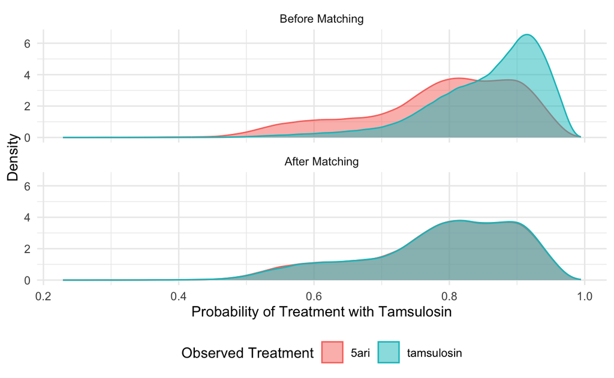

```r
ps <- read_rds(glue::glue("/{shared_dir}/lss_jsimmeri/LBD/model_tam_5ari_2rx.rds"))
bind_rows(
  model_data %>%
    inner_join(ps, by = "enrolid") %>%
    mutate(type = "Before Matching"),
  matched_model_data %>%
    inner_join(ps, by = "enrolid") %>%
    mutate(type = "After Matching")
  ) %>%
  mutate(type = forcats::fct_rev(type)) %>%
  ggplot(aes(x = ptx, fill = drug, color = drug)) +
  geom_density(alpha = 0.5) +
  labs(x = "Probability of Treatment with Tamsulosin",
       y = "Density",
       color = "Observed Treatment",
       fill = "Observed Treatment") +
  theme_minimal() +
  theme(legend.position = "bottom") +
  facet_wrap(~ type, nrow = 2)
```

## Survival Analysis

### Before Matching

Prior to matching, we observe a large survival difference with greater incidence among men taking tamsulosin then 5ARI.

```r
km_unadjust <-survfit(Surv(survival_time, develops_pd) ~ treatment,
        data = model_data) %>%
  broom::tidy() %>%
  mutate(treatment = ifelse(strata == "treatment=TRUE",
    "Tamsulosin", "5ARI")) %>%
  ggplot(
    aes(
      x = time / 365,
      y = 100 * estimate,
      ymin = 100 * conf.low,
      ymax = 100 * conf.high
    )
  ) +
  geom_step(aes(color = treatment)) +
  geom_ribbon(aes(fill = treatment), alpha = 0.25) +
  theme_minimal() +
  labs(x = "Years of Follow Up", y = "Percent Remaining PD Free",
       color = "", fill = "") +
  theme(legend.position = c(0.25, 0.25))
```

A finding that is statistically significant using the log rank test:

```r
survdiff(Surv(survival_time, develops_pd) ~ treatment,
         data = model_data)
```

```
Call:
survdiff(formula = Surv(survival_time, develops_pd) ~ treatment,
    data = model_data)

                     N Observed Expected (O-E)^2/E (O-E)^2/V
treatment=FALSE  80158      193      256     15.49      18.8
treatment=TRUE  437045     1286     1223      3.24      18.8

 Chisq= 18.8  on 1 degrees of freedom, p= 1e-05
```

```r
raw_cox <- coxph(Surv(survival_time, develops_pd) ~ as.numeric(treatment),
                 data = model_data,
                 robust = TRUE)
tbl_regression(raw_cox, exponentiate = TRUE)
```

| **Characteristic** | **HR**<sup>1</sup> | **95% CI**<sup>1</sup> | **p-value** |
| --- | --- | --- | --- |
| as.numeric(treatment) | 1.40 | 1.20, 1.62 | <0.001 |

<sup>1</sup> HR = Hazard Ratio, CI = Confidence Interval

However, this estimate is not trustworthy as we know the groups could be better balanced.

### With Propensity Score Matching

We observe the following overall incidence:

```r
matched_model_data %>%
  group_by(drug) %>%
  summarize(
    cases = sum(develops_pd),
    time = sum(survival_time / 365),
    incidence = cases / time * 10000
  ) %>%
  knitr::kable()
```

| drug | cases | time | incidence |
| --- | --- | --- | --- |
| 5ari | 192 | 246194.3 | 7.798718 |
| tamsulosin | 224 | 246086.1 | 9.102506 |

```r
km_adjust <-survfit(Surv(survival_time, develops_pd) ~ drug,
        data = matched_model_data) %>%
  broom::tidy() %>%
  mutate(treatment = ifelse(strata == "drug=tamsulosin",
    "Tamsulosin", "5ARI")) %>%
  ggplot(
    aes(
      x = time / 365,
      y = 100 * estimate,
      ymin = 100 * conf.low,
      ymax = 100 * conf.high
    )
  ) +
  geom_step(aes(color = treatment)) +
  geom_ribbon(aes(fill = treatment), alpha = 0.25) +
  theme_minimal() +
  labs(x = "Years of Follow Up", y = "Percent Remaining PD Free",
       color = "", fill = "") +
  theme(legend.position = c(0.25, 0.25))
```

The population size at risk by year is given in the table below:

```r
survfit(Surv(survival_time, develops_pd) ~ drug,
        data = matched_model_data) %>%
  broom::tidy() %>%
  select(strata, time,, n.risk) %>%
  complete(strata, time = 0:(16*365)) %>%
  fill(n.risk, .direction = "down") %>%
  mutate(drug = ifelse(strata == "drug=5ari", "5ARI", "Tamsulosin")) %>%
  select(time, drug, n.risk) %>%
  filter(time %in% c(1:16 * 365)) %>%
  mutate(year = round(time / 365)) %>%
  spread(drug, n.risk) %>%
  knitr::kable()
```

| time | year | 5ARI | Tamsulosin |
| --- | --- | --- | --- |
| 365 | 1 | 59311 | 59384 |
| 730 | 2 | 42426 | 42699 |
| 1095 | 3 | 30946 | 31090 |
| 1460 | 4 | 22571 | 22607 |
| 1825 | 5 | 16364 | 16437 |
| 2190 | 6 | 11709 | 11713 |
| 2555 | 7 | 8250 | 8354 |
| 2920 | 8 | 5591 | 5630 |
| 3285 | 9 | 3662 | 3637 |
| 3650 | 10 | 2290 | 2287 |
| 4015 | 11 | 1337 | 1330 |
| 4380 | 12 | 656 | 655 |
| 4745 | 13 | 334 | 345 |
| 5110 | 14 | 165 | 164 |
| 5475 | 15 | 43 | 42 |
| 5840 | 16 | 2 | 1 |

```r
survdiff(Surv(survival_time, develops_pd) ~ treatment,
         data = matched_model_data)
```

```
Call:
survdiff(formula = Surv(survival_time, develops_pd) ~ treatment,
    data = matched_model_data)

                N Observed Expected (O-E)^2/E (O-E)^2/V
treatment=0 79798      192      208      1.24      2.48
treatment=1 79798      224      208      1.24      2.48

 Chisq= 2.5  on 1 degrees of freedom, p= 0.1
```

Survival times

```r
tbl_survfit(
  survfit(
    Surv(survival_time, develops_pd) ~ drug, data = matched_model_data
  ),
  probs = seq(0.5, 2, by = 0.5) / 100
)
```

| **Characteristic** | **0.5% Percentile** | **1.0% Percentile** | **1.5% Percentile** | **2.0% Percentile** |
| --- | --- | --- | --- | --- |
| drug |  |  |  |  |
| 5ari | 2,079 (1,782, 2,718) | — (3,744, —) | — (—, —) | — (—, —) |
| tamsulosin | 2,230 (1,807, 2,501) | 3,281 (3,100, 3,808) | 4,209 (3,664, —) | 4,656 (4,355, —) |

We fit a Cox regression model to estimate the differences in hazard:

```r
full_cox <- coxph(Surv(survival_time, develops_pd) ~ as.numeric(treatment),
                       data = matched_model_data,
                       robust = TRUE)
tbl_regression(full_cox, exponentiate = TRUE)
```

| **Characteristic** | **HR**<sup>1</sup> | **95% CI**<sup>1</sup> | **p-value** |
| --- | --- | --- | --- |
| as.numeric(treatment) | 1.17 | 0.96, 1.42 | 0.12 |

<sup>1</sup> HR = Hazard Ratio, CI = Confidence Interval

## Fit Summaries

```r
tbl_merge(
  tbls = list(
    tbl_regression(raw_cox, exponentiate = TRUE),
    tbl_regression(full_cox, exponentiate = TRUE)
  ),
  tab_spanner = c("Unadjusted", "Propensity Score Matched")
) %>%
  as_flex_table()
```

| Characteristic | Unadjusted HR1 | Unadjusted 95% CI1 | Unadjusted p-value | Propensity Score Matched HR1 | Propensity Score Matched 95% CI1 | Propensity Score Matched p-value |
| --- | --- | --- | --- | --- | --- | --- |
| as.numeric(treatment) | 1.40 | 1.20, 1.62 | <0.001 | 1.17 | 0.96, 1.42 | 0.12 |

1HR = Hazard Ratio, CI = Confidence Interval

## Diagnostics

```r
scf_residuals <- cox.zph(full_cox)
scf_residuals
```

```
                      chisq df      p
as.numeric(treatment)  6.81  1 0.0091
GLOBAL                 6.81  1 0.0091
```

```r
with(scf_residuals, cor.test(x, y))
```

```
    Pearson's product-moment correlation

data:  x and y
t = 2.6239, df = 414, p-value = 0.009013
alternative hypothesis: true correlation is not equal to 0
95 percent confidence interval:
 0.03214985 0.22132410
sample estimates:
      cor
0.1279001
```

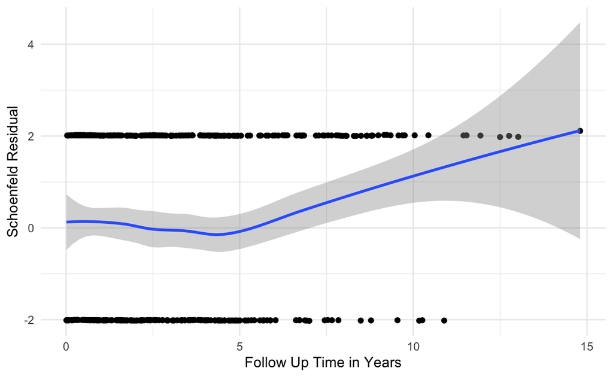

```r
tibble(
  x = scf_residuals$time,
  y = scf_residuals$y
) %>%
  ggplot(aes(x = x / 365, y = y)) +
  geom_point() +
  geom_smooth(method = "loess") +
  labs(x = "Follow Up Time in Years", y = "Schoenfeld Residual") +
  theme_minimal()
```